# Counting reads with Subread

September 2019

## Counting

Once our reads have been aligned against the genome, we need to summarise the information across genes or exons. We can determine if the region each read is aligned to corresponds to a particular gene or exon and then summarise across the entire BAM file to get total read counts for each gene or exon.

We will use **`featureCounts`** [@Liao2014] programme from the [subRead package](http://subread.sourceforge.net/) to do the counting. In addition to the BAM files, we also need to provide **`featureCounts`** with an annotation file. Usually this will be a GTF/GFF file corresponding to the genome assembly used.

## GTF file format

GTF/GFF files define genomic regions covered by different types of genomic features, e.g. genes, transcripts, exons, or UTRs. The necessary GTF is already in the directory `Course_Materials/data`.

## Using FeatureCounts

When using a GTF/GFF file we need to tell **`featureCounts`** what feature type to use to count reads, and what attribute type to summarise the results at. For RNAseq we most commonly wish to count reads aligning to exons, and then to summarise at the gene level.

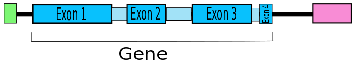

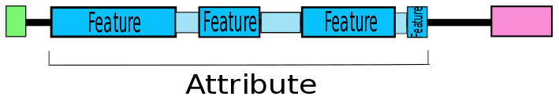

## Running FeatureCounts

The code below uses **`featureCounts`** to count reads in a BAM file against a GTF for the mouse GRCm38 genome assembly.

```
  mkdir counts

  featureCounts \
      -t exon \
      -g gene_id \
      --primary \
      -a references/Mus_musculus.GRCm38.97.gtf \
      -o counts/MCL1.DL.featureCounts \
      bam/MCL1.DL.sorted.bam
```

- **`-t exon`** - the **feature** type to count reads against, in this case exons
- **`-g gene_id`** - the **attribute** type to summarise counts by, in this case the gene ID
- **`--primary`** - only count primary alignment
- **`-a`** - the gene annotation reference file
- **`-o`** - the name for the output files

**`featureCounts`** has many additional options that can be used to alter the ways in which it does the counting.

```
featureCounts --help
```

## Exercise

[output not shown]

The summary table reports the numbers of unassigned reads and the reasons why they are not assigned (eg. ambiguity, multi-mapping, secondary alignment, mapping quality, fragment length, chimera, read duplicate, non-junction and so on), in addition to the number of successfully assigned reads for each library. See [subread documentation](http://bioinf.wehi.edu.au/subread-package/SubreadUsersGuide.pdf) ('Program output' section).

[output not shown]

The full results table begins with a line containing the command used to generate the counts. It then has a table of 7 columns:

1. The gene identifier; this will vary depending on the GTF file used, in our case this is an Ensembl gene id
2. Chromosome
3. Start position for each exon in the gene
4. End position for each exon in the gene
5. Transcription strand for each exon in the gene
6. The total length of the gene in nucleotides
7. The number of reads assigned to the gene.

Note that **`featureCounts`** outputs a row for every gene in the GTF, even the ones with no reads assigned, and the row order is determined by the order in the GTF. This means that if featureCounts is used on mutliple samples with same GTF file, the separate files can be combined easily as the rows always refer to the same gene.

In fact we can have **`featureCounts`** do this for us by running all of our libraries together in one command. To save time for this we will use versions of our BAM files that only include alignments to chromosome 15. You can find these in **`small_bams`** directory. There is also a chromosome 15 only gtf in the reference directory.

```
  featureCounts \
      -t exon \
      -g gene_id \
      --primary \
      -a references/Mus_musculus.GRCm38.97.chr15.gtf  \
      -o counts/GSE60450_Lactation.chr15.featureCounts \
      small_bams/MCL*.bam
```

This gives us a combined counts table as an output with the first 6 columns as before but now the folowing columns contain the counts for all of the samples.

[output not shown]

### Exercise 1

1. Redo the counting for your sorted bam over the exons, rather than the genes. Use `featureCounts --help` to find the option you need to use. Make sure featureCounts outputs the results to a new file.
2. Redo the counting over genes, allowing for multimapping reads. Compare the results to our intial counts.